# Group6_CSCN8010_Final_Project

## Problem Statement

### Context

Business communities in the United States are facing high demand for human resources, but one of the constant challenges is identifying and attracting the right talent, which is perhaps the most important element in remaining competitive. Companies in the United States look for hard-working, talented, and qualified individuals both locally as well as abroad. The Immigration and Nationality Act (INA) of the US permits foreign workers to come to the United States to work on either a temporary or permanent basis. The act also protects US workers against adverse impacts on their wages or working conditions by ensuring US employers' compliance with statutory requirements when they hire foreign workers to fill workforce shortages. The immigration programs are administered by the Office of Foreign Labor Certification (OFLC). OFLC processes job certification applications for employers seeking to bring foreign workers into the United States and grants certifications in those cases where employers can demonstrate that there are not sufficient US workers available to perform the work at wages that meet or exceed the wage paid for the occupation in the area of intended employment. Objective In FY 2016, the OFLC processed 775,979 employer applications for 1,699,957 positions for temporary and permanent labor certifications. This was a nine percent increase in the overall number of processed applications from the previous year. The process of reviewing every case is becoming a tedious task as the number of applicants is increasing every year. The increasing number of applicants every year calls for a Machine Learning based solution that can help in shortlisting the candidates having higher chances of VISA approval. OFLC has hired the firm EasyVisa for data-driven solutions. You as a data scientist at EasyVisa have to analyze the data provided and, with the help of a classification model:

1. Facilitate the process of visa approvals.
2. Recommend a suitable profile for the applicants for whom the visa should be certified or denied based on the drivers that significantly influence the case status.

### Data Description

The data contains the different attributes of the employee and the employer. The detailed data dictionary is given below.

• case_id: ID of each visa application

• continent: Information of continent the employee

• education_of_employee: Information of education of the employee

• has_job_experience: Does the employee has any job experience? Y= Yes; N = No

• requires_job_training: Does the employee require any job training? Y = Yes; N = No

• no_of_employees: Number of employees in the employer's company

• yr_of_estab: Year in which the employer's company was established

• region_of_employment: Information of foreign worker's intended region of employment in the US.

• prevailing_wage: Average wage paid to similarly employed workers in a specific occupation in the area of intended employment. The purpose of the prevailing wage is to ensure that the foreign worker is not underpaid compared to other workers offering the same or similar service in the same area of employment.

• unit_of_wage: Unit of prevailing wage. Values include Hourly, Weekly, Monthly, and Yearly.

• full_time_position: Is the position of work full-time? Y = Full-Time Position; N = Part-Time Position

• case_status: Flag indicating if the Visa was certified or denied

## Importing necessary libraries

```python
# Libraries to help with reading and manipulating data
import pandas as pd
import numpy as np

# To suppress scientific notations
pd.set_option("display.float_format", lambda x: "%.3f" % x)

# Libaries to help with data visualization
import matplotlib.pyplot as plt
import seaborn as sns

# To tune model, get different metric scores, and split data
from sklearn import metrics
from sklearn.metrics import (
    f1_score,
    accuracy_score,
    recall_score,
    precision_score,
    confusion_matrix,
    roc_auc_score,
)
from sklearn.model_selection import train_test_split, StratifiedKFold, cross_val_score

# To be used for data scaling and one hot encoding
from sklearn.preprocessing import StandardScaler, MinMaxScaler, OneHotEncoder

# To impute missing values
from sklearn.impute import SimpleImputer

# To oversample and undersample data
from imblearn.over_sampling import SMOTE
from imblearn.under_sampling import RandomUnderSampler

# To do hyperparameter tuning
from sklearn.model_selection import RandomizedSearchCV

# To define maximum number of columns to be displayed in a dataframe
pd.set_option("display.max_columns", None)

# To supress scientific notations for a dataframe
pd.set_option("display.float_format", lambda x: "%.3f" % x)

# To help with model building
from sklearn.tree import DecisionTreeClassifier
from sklearn.ensemble import (
    AdaBoostClassifier,
    GradientBoostingClassifier,
    RandomForestClassifier,
    BaggingClassifier,
)
from xgboost import XGBClassifier

# To supress warnings
import warnings
warnings.filterwarnings("ignore")
```

## Loading the dataset

```python
visa = pd.read_csv("/content/drive/MyDrive/EasyVisa.csv")
```

## Data Overview

The initial steps to get an overview of any dataset is to:

- observe the first few rows of the dataset, to check whether the dataset has been loaded properly or not
- get information about the number of rows and columns in the dataset
- find out the data types of the columns to ensure that data is stored in the preferred format and the value of each property is as expected.
- check the statistical summary of the dataset to get an overview of the numerical columns of the data

### Checking the shape of the dataset

```python
# Checking the number of rows and columns in the training data
print(f"The Data has {visa.shape[0]} rows and {visa.shape[1]} columns")
```

```
The Data has 25480 rows and 12 columns
```

```python
# create a copy of the data
data = visa.copy()
```

### Displaying the first few rows of the dataset

```python
# The first 5 rows of the data
data.head() ##  Complete the code to view top 5 rows of the data
```

|  | case_id | continent | education_of_employee | has_job_experience | requires_job_training | no_of_employees | yr_of_estab | region_of_employment | prevailing_wage | unit_of_wage | full_time_position | case_status |
| --- | --- | --- | --- | --- | --- | --- | --- | --- | --- | --- | --- | --- |
| 0 | EZYV01 | Asia | High School | N | N | 14513 | 2007 | West | 592.203 | Hour | Y | Denied |
| 1 | EZYV02 | Asia | Master's | Y | N | 2412 | 2002 | Northeast | 83425.650 | Year | Y | Certified |
| 2 | EZYV03 | Asia | Bachelor's | N | Y | 44444 | 2008 | West | 122996.860 | Year | Y | Denied |
| 3 | EZYV04 | Asia | Bachelor's | N | N | 98 | 1897 | West | 83434.030 | Year | Y | Denied |
| 4 | EZYV05 | Africa | Master's | Y | N | 1082 | 2005 | South | 149907.390 | Year | Y | Certified |

```python
# The last 5 rows of the data
data.tail()
```

|  | case_id | continent | education_of_employee | has_job_experience | requires_job_training | no_of_employees | yr_of_estab | region_of_employment | prevailing_wage | unit_of_wage | full_time_position | case_status |
| --- | --- | --- | --- | --- | --- | --- | --- | --- | --- | --- | --- | --- |
| 25475 | EZYV25476 | Asia | Bachelor's | Y | Y | 2601 | 2008 | South | 77092.570 | Year | Y | Certified |
| 25476 | EZYV25477 | Asia | High School | Y | N | 3274 | 2006 | Northeast | 279174.790 | Year | Y | Certified |
| 25477 | EZYV25478 | Asia | Master's | Y | N | 1121 | 1910 | South | 146298.850 | Year | N | Certified |
| 25478 | EZYV25479 | Asia | Master's | Y | Y | 1918 | 1887 | West | 86154.770 | Year | Y | Certified |
| 25479 | EZYV25480 | Asia | Bachelor's | Y | N | 3195 | 1960 | Midwest | 70876.910 | Year | Y | Certified |

### Checking the data types of the columns for the dataset

```python
# Check the data types of the columns in the dataset
data.info()
```

```
<class 'pandas.core.frame.DataFrame'>
RangeIndex: 25480 entries, 0 to 25479
Data columns (total 12 columns):
 #   Column                 Non-Null Count  Dtype
---  ------                 --------------  -----
 0   case_id                25480 non-null  object
 1   continent              25480 non-null  object
 2   education_of_employee  25480 non-null  object
 3   has_job_experience     25480 non-null  object
 4   requires_job_training  25480 non-null  object
 5   no_of_employees        25480 non-null  int64
 6   yr_of_estab            25480 non-null  int64
 7   region_of_employment   25480 non-null  object
 8   prevailing_wage        25480 non-null  float64
 9   unit_of_wage           25480 non-null  object
 10  full_time_position     25480 non-null  object
 11  case_status            25480 non-null  object
dtypes: float64(1), int64(2), object(9)
memory usage: 2.3+ MB
```

The data has:

9 columns of object datatype

2 columns of int datatype

1 column of float datatype

### Checking for duplicate values

```python
# Check for duplicate values in the data
data.duplicated().sum()
```

```
np.int64(0)
```

There are no duplicates in the data

### Checking for missing values

```python
#check for missing values in the data

#data.isna().sum()
data.isnull().sum()
```

|  | 0 |
| --- | --- |
| case_id | 0 |
| continent | 0 |
| education_of_employee | 0 |
| has_job_experience | 0 |
| requires_job_training | 0 |
| no_of_employees | 0 |
| yr_of_estab | 0 |
| region_of_employment | 0 |
| prevailing_wage | 0 |
| unit_of_wage | 0 |
| full_time_position | 0 |
| case_status | 0 |

**dtype:** int64

There are no missing values in the data

### Statistical summary of the dataset

```python
# the statistical summary of the numerical columns in the data
data.describe().T
```

|  | count | mean | std | min | 25% | 50% | 75% | max |
| --- | --- | --- | --- | --- | --- | --- | --- | --- |
| no_of_employees | 25480.000 | 5667.043 | 22877.929 | -26.000 | 1022.000 | 2109.000 | 3504.000 | 602069.000 |
| yr_of_estab | 25480.000 | 1979.410 | 42.367 | 1800.000 | 1976.000 | 1997.000 | 2005.000 | 2016.000 |
| prevailing_wage | 25480.000 | 74455.815 | 52815.942 | 2.137 | 34015.480 | 70308.210 | 107735.513 | 319210.270 |

from the above statistical summary, we can deduce that

1. mean number of employees is 5667 and max is 602069. with 50% of the companies have around 2109 or less employees

The min number employees is -26, which doesnt make sense.

2. yr_of_estab: The range of the year of the establishment of the companies range from the year 1800 to 2016.

About half of the companies are older than 1997.

3. prewailing_wage: mean is around 74455. Min prewailing wage is 2.137( which needs investigation). Max value is 319210.

No_of_employees

```python
zeroEmpCount = len(data[data['no_of_employees'] == 0])
print(f"There are in total {zeroEmpCount} entries or records with zero number of employees\n")
negEmpCount = len(data[data['no_of_employees'] < 0])
print(f"There are in total {negEmpCount} entries or records with negative number of employees")
```

```
There are in total 0 entries or records with zero number of employees

There are in total 33 entries or records with negative number of employees
```

```python
print(data[data['no_of_employees']<0].value_counts())
```

```
case_id    continent      education_of_employee  has_job_experience  requires_job_training  no_of_employees  yr_of_estab  region_of_employment  prevailing_wage  unit_of_wage  full_time_position  case_status
EZYV11494  Asia           High School            Y                   N                      -14              1999         South                 27599.350        Year          Y                   Denied         1
EZYV13472  North America  Master's               N                   N                      -17              2003         Northeast             257.241          Hour          Y                   Denied         1
EZYV14023  Asia           Bachelor's             N                   Y                      -11              1946         Northeast             108403.560       Year          Y                   Certified      1
EZYV14147  Asia           Bachelor's             N                   Y                      -26              1954         West                  81982.270        Year          Y                   Certified      1
EZYV14727  Asia           Master's               N                   N                      -11              2000         Midwest               167851.800       Year          Y                   Certified      1
EZYV15601  Asia           Bachelor's             N                   N                      -14              2014         South                 24641.610        Year          Y                   Denied         1
EZYV15860  Asia           High School            N                   N                      -11              1969         South                 44640.600        Year          Y                   Denied         1
EZYV16158  Asia           Master's               Y                   N                      -11              1994         South                 62681.250        Year          Y                   Certified      1
EZYV16884  North America  Bachelor's             Y                   N                      -26              1968         Northeast             168.156          Hour          Y                   Denied         1
EZYV17007  Asia           Doctorate              Y                   N                      -11              1984         West                  25753.510        Year          Y                   Denied         1
EZYV17656  North America  Bachelor's             Y                   N                      -17              2007         Northeast             129753.180       Year          Y                   Denied         1
EZYV17845  Asia           Bachelor's             N                   N                      -14              2012         West                  29325.850        Year          Y                   Denied         1
EZYV17984  Asia           Bachelor's             N                   N                      -26              2004         South                 84359.980        Year          Y                   Denied         1
EZYV20816  Asia           Bachelor's             N                   Y                      -17              1990         West                  91897.570        Year          Y                   Certified      1
EZYV20985  Europe         Doctorate              Y                   N                      -14              1989         Midwest               37012.800        Year          Y                   Certified      1
EZYV21256  North America  High School            N                   N                      -25              1987         South                 99405.470        Year          N                   Denied         1
EZYV21761  Asia           Bachelor's             Y                   N                      -25              2000         West                  100463.580       Year          Y                   Certified      1
EZYV21945  Africa         Master's               Y                   N                      -25              1977         Midwest               79150.510        Year          Y                   Certified      1
EZYV22085  North America  Bachelor's             Y                   N                      -14              1980         West                  691.061          Hour          Y                   Denied         1
EZYV22389  Asia           Master's               Y                   N                      -14              1986         South                 17893.110        Year          Y                   Certified      1
EZYV23187  Asia           Master's               N                   Y                      -11              2007         Midwest               120195.350       Year          Y                   Certified      1
EZYV23477  Europe         Master's               Y                   N                      -11              2000         West                  95072.750        Year          Y                   Denied         1
```

[output cut: 12 more lines]

WE will impute the negative values with median of the positive values of the data after splitting the data into train, validation and test datasets and apply the imputation separately for each dataset. This step will prevent data leakage.

prevailing_Wage

```python
# Group by 'unit_of_wage' and get the minimum and max 'prevailing_wage' for each group
min_wage_by_unit = data.groupby('unit_of_wage')['prevailing_wage'].min()
max_wage_by_unit = data.groupby('unit_of_wage')['prevailing_wage'].max()
print(min_wage_by_unit)
print(max_wage_by_unit)
```

```
unit_of_wage
Hour       2.137
Month   1599.280
Week    2183.230
Year     100.000
Name: prevailing_wage, dtype: float64
unit_of_wage
Hour       999.919
Month   264362.950
Week    280175.950
Year    319210.270
Name: prevailing_wage, dtype: float64
```

```python
data.groupby('unit_of_wage')['prevailing_wage'].describe()
```

| unit_of_wage | count | mean | std | min | 25% | 50% | 75% | max |
| --- | --- | --- | --- | --- | --- | --- | --- | --- |
| Hour | 2157.000 | 414.571 | 275.015 | 2.137 | 152.700 | 372.652 | 637.311 | 999.919 |
| Month | 89.000 | 87592.864 | 59525.125 | 1599.280 | 44986.240 | 81826.010 | 121629.600 | 264362.950 |
| Week | 272.000 | 85606.821 | 44802.705 | 2183.230 | 51408.277 | 85075.820 | 111331.910 | 280175.950 |
| Year | 22962.000 | 81228.077 | 49951.473 | 100.000 | 43715.955 | 76174.500 | 111341.960 | 319210.270 |

From the above result, we can see that for each unit_of_wage, there are several values of prevailing_wage. In other words, there are several entries of prevailing_wages for hourly, weekly, monthly and yearly type of wage.

This data will need to be properly categorized for better analysis. We will perform this after splitting the data to prevent data leakage.

```python
data[data['prevailing_wage']>900][data['unit_of_wage']=='Hour']
```

|  | case_id | continent | education_of_employee | has_job_experience | requires_job_training | no_of_employees | yr_of_estab | region_of_employment | prevailing_wage | unit_of_wage | full_time_position | case_status |
| --- | --- | --- | --- | --- | --- | --- | --- | --- | --- | --- | --- | --- |
| 672 | EZYV673 | Asia | Master's | N | N | 111654 | 2012 | Northeast | 963.068 | Hour | Y | Denied |
| 1212 | EZYV1213 | Asia | High School | N | N | 31859 | 1964 | South | 932.980 | Hour | Y | Certified |
| 2036 | EZYV2037 | Asia | High School | Y | N | 4569 | 1946 | South | 916.345 | Hour | Y | Certified |
| 2082 | EZYV2083 | Asia | Bachelor's | Y | N | 1323 | 1962 | Northeast | 959.773 | Hour | Y | Certified |
| 2152 | EZYV2153 | Asia | Bachelor's | Y | N | 3095 | 1967 | South | 994.181 | Hour | Y | Certified |
| ... | ... | ... | ... | ... | ... | ... | ... | ... | ... | ... | ... | ... |
| 24219 | EZYV24220 | North America | Bachelor's | N | N | 1290 | 1890 | Northeast | 911.025 | Hour | Y | Denied |
| 24330 | EZYV24331 | Asia | Bachelor's | N | N | 1532 | 2009 | Northeast | 987.928 | Hour | Y | Certified |
| 24747 | EZYV24748 | North America | Master's | N | N | 182 | 1977 | West | 961.735 | Hour | Y | Certified |
| 24878 | EZYV24879 | Asia | Master's | N | N | 1733 | 1831 | South | 951.768 | Hour | Y | Certified |
| 25064 | EZYV25065 | Asia | Master's | Y | N | 1037 | 2012 | South | 937.079 | Hour | Y | Denied |

109 rows × 12 columns

```python
print(data[data['prevailing_wage']<20].value_counts())
```

```
case_id    continent      education_of_employee  has_job_experience  requires_job_training  no_of_employees  yr_of_estab  region_of_employment  prevailing_wage  unit_of_wage  full_time_position  case_status
EZYV10007  North America  Master's               N                   N                      2816             1974         Northeast             9.533            Hour          Y                   Denied         1
EZYV10112  Asia           Master's               N                   N                      2280             1977         West                  16.060           Hour          Y                   Certified      1
EZYV10920  Asia           Doctorate              N                   N                      605              1996         Northeast             17.475           Hour          Y                   Certified      1
EZYV1216   Asia           Bachelor's             N                   N                      1814             2002         Northeast             10.555           Hour          Y                   Denied         1
EZYV1239   South America  Doctorate              N                   N                      1998             1992         West                  16.464           Hour          Y                   Denied         1
EZYV1334   Asia           Bachelor's             Y                   N                      3754             1963         South                 17.519           Hour          Y                   Certified      1
EZYV13545  North America  High School            Y                   N                      3191             2003         Northeast             5.090            Hour          Y                   Denied         1
EZYV14918  Asia           Master's               N                   N                      2613             2013         Northeast             16.732           Hour          Y                   Denied         1
EZYV15978  Asia           Bachelor's             N                   N                      3034             2003         South                 11.422           Hour          Y                   Certified      1
EZYV17034  Asia           Master's               Y                   N                      2587             1989         South                 7.065            Hour          Y                   Certified      1
EZYV17449  South America  Master's               Y                   N                      4421             1999         Northeast             3.003            Hour          Y                   Denied         1
EZYV19426  North America  Bachelor's             Y                   N                      2051             2004         Northeast             5.187            Hour          Y                   Denied         1
EZYV19594  Asia           Master's               N                   N                      528              2004         Northeast             5.411            Hour          Y                   Certified      1
EZYV19726  Asia           Bachelor's             N                   Y                      2228             2007         Northeast             17.891           Hour          Y                   Certified      1
EZYV2011   Asia           Bachelor's             N                   N                      709              2005         West                  10.111           Hour          Y                   Denied         1
EZYV20483  North America  Bachelor's             N                   N                      2584             1900         South                 6.330            Hour          Y                   Denied         1
EZYV20576  North America  Master's               N                   N                      1552             2004         Northeast             2.137            Hour          Y                   Certified      1
EZYV22156  Asia           Bachelor's             N                   N                      548              2009         South                 12.990           Hour          Y                   Denied         1
EZYV22856  North America  High School            Y                   N                      564              1991         South                 2.956            Hour          Y                   Denied         1
EZYV23417  Europe         Bachelor's             N                   N                      1456             2008         Northeast             9.175            Hour          Y                   Denied         1
EZYV23739  Asia           High School            Y                   N                      2725             1992         Northeast             11.308           Hour          Y                   Denied         1
EZYV2861   Asia           Master's               N                   N                      3173             2007         West                  18.442           Hour          Y                   Denied         1
EZYV339    Asia           Bachelor's             Y                   N                      2114             2012         Northeast             15.772           Hour          Y                   Certified      1
```

[output cut: 13 more lines]

Lets check the statistical summary of the number of employees column

```python
data.describe().T
```

|  | count | mean | std | min | 25% | 50% | 75% | max |
| --- | --- | --- | --- | --- | --- | --- | --- | --- |
| no_of_employees | 25480.000 | 5667.043 | 22877.929 | -26.000 | 1022.000 | 2109.000 | 3504.000 | 602069.000 |
| yr_of_estab | 25480.000 | 1979.410 | 42.367 | 1800.000 | 1976.000 | 1997.000 | 2005.000 | 2016.000 |
| prevailing_wage | 25480.000 | 74455.815 | 52815.942 | 2.137 | 34015.480 | 70308.210 | 107735.513 | 319210.270 |

```python
# STatistical summary of all columns in the data including their datatype
data_summary = data.describe(include='all').T
data_summary['Data Type'] = data.dtypes
data_summary.sort_values(by='Data Type', ascending=False)
```

|  | count | unique | top | freq | mean | std | min | 25% | 50% | 75% | max | Data Type |
| --- | --- | --- | --- | --- | --- | --- | --- | --- | --- | --- | --- | --- |
| case_id | 25480 | 25480 | EZYV25480 | 1 | NaN | NaN | NaN | NaN | NaN | NaN | NaN | object |
| continent | 25480 | 6 | Asia | 16861 | NaN | NaN | NaN | NaN | NaN | NaN | NaN | object |
| education_of_employee | 25480 | 4 | Bachelor's | 10234 | NaN | NaN | NaN | NaN | NaN | NaN | NaN | object |
| has_job_experience | 25480 | 2 | Y | 14802 | NaN | NaN | NaN | NaN | NaN | NaN | NaN | object |
| requires_job_training | 25480 | 2 | N | 22525 | NaN | NaN | NaN | NaN | NaN | NaN | NaN | object |
| region_of_employment | 25480 | 5 | Northeast | 7195 | NaN | NaN | NaN | NaN | NaN | NaN | NaN | object |
| unit_of_wage | 25480 | 4 | Year | 22962 | NaN | NaN | NaN | NaN | NaN | NaN | NaN | object |
| full_time_position | 25480 | 2 | Y | 22773 | NaN | NaN | NaN | NaN | NaN | NaN | NaN | object |
| case_status | 25480 | 2 | Certified | 17018 | NaN | NaN | NaN | NaN | NaN | NaN | NaN | object |
| prevailing_wage | 25480.000 | NaN | NaN | NaN | 74455.815 | 52815.942 | 2.137 | 34015.480 | 70308.210 | 107735.513 | 319210.270 | float64 |
| no_of_employees | 25480.000 | NaN | NaN | NaN | 5667.043 | 22877.929 | -26.000 | 1022.000 | 2109.000 | 3504.000 | 602069.000 | int64 |
| yr_of_estab | 25480.000 | NaN | NaN | NaN | 1979.410 | 42.367 | 1800.000 | 1976.000 | 1997.000 | 2005.000 | 2016.000 | int64 |

```python
for i in data.describe(include=["object"]).columns:
    print("\nUnique values in", i, "are :\n")
    print(data[i].value_counts())
    print("*" * 50)
```

```
Unique values in case_id are :

case_id
EZYV25480    1
EZYV01       1
EZYV02       1
EZYV03       1
EZYV04       1
            ..
EZYV13       1
EZYV12       1
EZYV11       1
EZYV10       1
EZYV09       1
Name: count, Length: 25480, dtype: int64

Unique values in continent are :

continent
Asia             16861
Europe            3732
North America     3292
South America      852
Africa             551
Oceania            192
Name: count, dtype: int64

Unique values in education_of_employee are :

education_of_employee
Bachelor's     10234
Master's        9634
High School     3420
Doctorate       2192
Name: count, dtype: int64

Unique values in has_job_experience are :

has_job_experience
Y    14802
```

[output cut: 27 more lines]

```
Name: count, dtype: int64

Unique values in full_time_position are :

full_time_position
Y    22773
N     2707
Name: count, dtype: int64

Unique values in case_status are :

case_status
Certified    17018
Denied        8462
Name: count, dtype: int64
```

```python
# CaseID is a unique ID of  each visa application (every record) and it will not add value to the modeling. Hence will drop it.
data.drop(["case_id"], axis=1, inplace=True)
```

```python
data.info()
```

```
<class 'pandas.core.frame.DataFrame'>
RangeIndex: 25480 entries, 0 to 25479
Data columns (total 11 columns):
 #   Column                 Non-Null Count  Dtype
---  ------                 --------------  -----
 0   continent              25480 non-null  object
 1   education_of_employee  25480 non-null  object
 2   has_job_experience     25480 non-null  object
 3   requires_job_training  25480 non-null  object
 4   no_of_employees        25480 non-null  int64
 5   yr_of_estab            25480 non-null  int64
 6   region_of_employment   25480 non-null  object
 7   prevailing_wage        25480 non-null  float64
 8   unit_of_wage           25480 non-null  object
 9   full_time_position     25480 non-null  object
 10  case_status            25480 non-null  object
dtypes: float64(1), int64(2), object(8)
memory usage: 2.1+ MB
```

```python
## replacing the values of certified to 0 and denied to 1 for analysis purposes
data["case_status"].replace("Certified", 0, inplace=True)
data["case_status"].replace("Denied", 1, inplace=True)
data["case_status"].value_counts()
```

| case_status | count |
| --- | --- |
| 0 | 17018 |
| 1 | 8462 |

**dtype:** int64

## Exploratory Data Analysis

#### The below functions need to be defined to carry out the Exploratory Data Analysis.

```python
# function to plot a boxplot and a histogram along the same scale.


def histogram_boxplot(data, feature, figsize=(12, 7), kde=False, bins=None):
    """
    Boxplot and histogram combined

    data: dataframe
    feature: dataframe column
    figsize: size of figure (default (12,7))
    kde: whether to the show density curve (default False)
    bins: number of bins for histogram (default None)
    """
    f2, (ax_box2, ax_hist2) = plt.subplots(
        nrows=2,  # Number of rows of the subplot grid= 2
        sharex=True,  # x-axis will be shared among all subplots
        gridspec_kw={"height_ratios": (0.25, 0.75)},
        figsize=figsize,
    )  # creating the 2 subplots
    sns.boxplot(
        data=data, x=feature, ax=ax_box2, showmeans=True, color="violet"
    )  # boxplot will be created and a triangle will indicate the mean value of the column
    sns.histplot(
        data=data, x=feature, kde=kde, ax=ax_hist2, bins=bins, palette="winter"
    ) if bins else sns.histplot(
        data=data, x=feature, kde=kde, ax=ax_hist2
    )  # For histogram
    ax_hist2.axvline(
        data[feature].mean(), color="green", linestyle="--"
    )  # Add mean to the histogram
    ax_hist2.axvline(
        data[feature].median(), color="black", linestyle="-"
    )  # Add median to the histogram
```

```python
# function to create labeled barplots


def labeled_barplot(data, feature, perc=False, n=None):
    """
    Barplot with percentage at the top

    data: dataframe
    feature: dataframe column
    perc: whether to display percentages instead of count (default is False)
    n: displays the top n category levels (default is None, i.e., display all levels)
    """

    total = len(data[feature])  # length of the column
    count = data[feature].nunique()
    if n is None:
        plt.figure(figsize=(count + 1, 5))
    else:
        plt.figure(figsize=(n + 1, 5))

    plt.xticks(rotation=90, fontsize=15)
    ax = sns.countplot(
        data=data,
        x=feature,
        palette="Paired",
        order=data[feature].value_counts().index[:n].sort_values(),
    )

    for p in ax.patches:
        if perc == True:
            label = "{:.1f}%".format(
                100 * p.get_height() / total
            )  # percentage of each class of the category
        else:
            label = p.get_height()  # count of each level of the category

        x = p.get_x() + p.get_width() / 2  # width of the plot
        y = p.get_height()  # height of the plot

        ax.annotate(
            label,
            (x, y),
            ha="center",
            va="center",
            size=12,
            xytext=(0, 5),
            textcoords="offset points",
        )  # annotate the percentage

    plt.show()  # show the plot
```

```python
# function to plot stacked bar chart

def stacked_barplot(data, predictor, target):
    """
    Print the category counts and plot a stacked bar chart

    data: dataframe
    predictor: independent variable
    target: target variable
    """
    count = data[predictor].nunique()
    sorter = data[target].value_counts().index[-1]
    tab1 = pd.crosstab(data[predictor], data[target], margins=True).sort_values(
        by=sorter, ascending=False
    )
    print(tab1)
    print("-" * 120)
    tab = pd.crosstab(data[predictor], data[target], normalize="index").sort_values(
        by=sorter, ascending=False
    )
    tab.plot(kind="bar", stacked=True, figsize=(count + 1, 5))
    plt.legend(
        loc="lower left", frameon=False,
    )
    plt.legend(loc="upper left", bbox_to_anchor=(1, 1))
    plt.show()
```

```python
### Function to plot distributions

def distribution_plot_wrt_target(data, predictor, target):

    fig, axs = plt.subplots(2, 2, figsize=(12, 10))

    target_uniq = data[target].unique()

    axs[0, 0].set_title("Distribution of target for target=" + str(target_uniq[0]))
    sns.histplot(
        data=data[data[target] == target_uniq[0]],
        x=predictor,
        kde=True,
        ax=axs[0, 0],
        color="teal",
    )

    axs[0, 1].set_title("Distribution of target for target=" + str(target_uniq[1]))
    sns.histplot(
        data=data[data[target] == target_uniq[1]],
        x=predictor,
        kde=True,
        ax=axs[0, 1],
        color="orange",
    )

    axs[1, 0].set_title("Boxplot w.r.t target")
    sns.boxplot(data=data, x=target, y=predictor, ax=axs[1, 0], palette="gist_rainbow")

    axs[1, 1].set_title("Boxplot (without outliers) w.r.t target")
    sns.boxplot(
        data=data,
        x=target,
        y=predictor,
        ax=axs[1, 1],
        showfliers=False,
        palette="gist_rainbow",
    )

    plt.tight_layout()
    plt.show()
```

### Univariate analysis

#### Numeric Fields

```python
# Extract numeric columns from the dataframe
numericCols = data.select_dtypes(include=["int64", "float64"]).columns
numericCols
```

```
Index(['no_of_employees', 'yr_of_estab', 'prevailing_wage', 'case_status'], dtype='object')
```

Number of employees

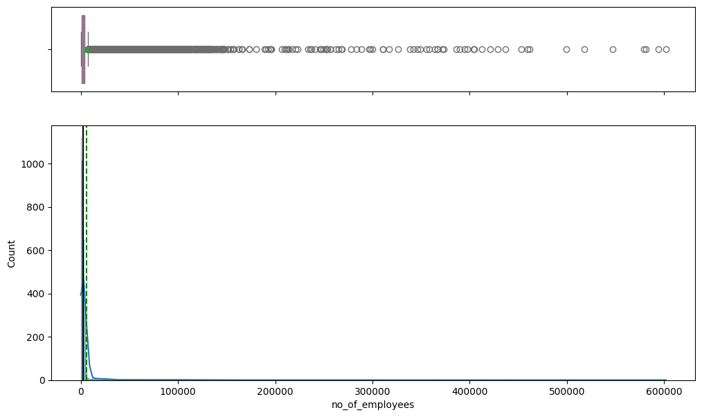

```python
histogram_boxplot(data, 'no_of_employees',kde=True);
```

It has a lot of outliers.

The data is right skewed

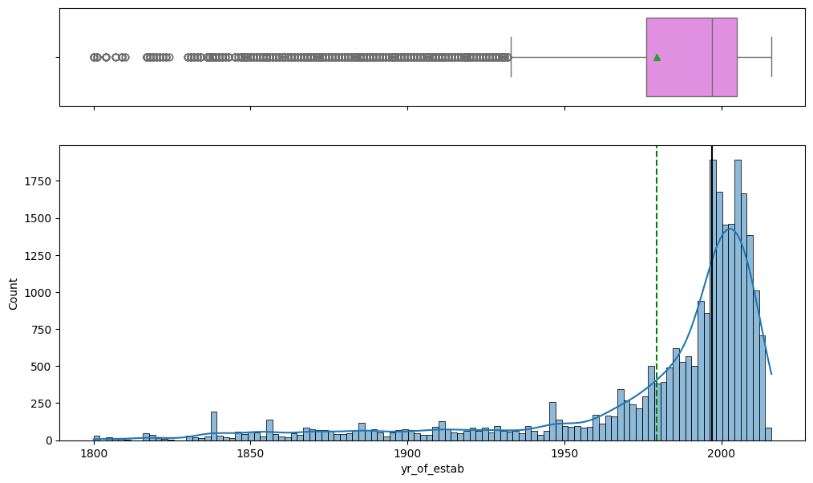

```python
histogram_boxplot(data,'yr_of_estab',kde=True)
```

The data is not normally distributed.

prevailing_wage

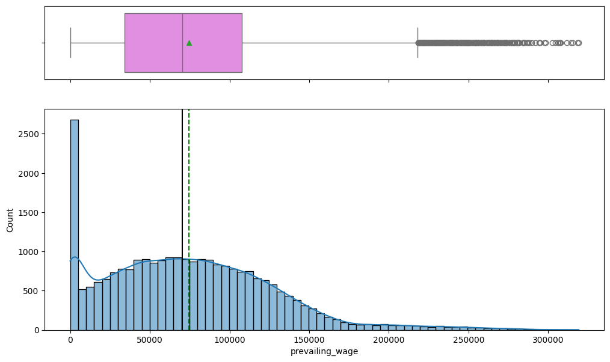

```python
histogram_boxplot(data,'prevailing_wage',kde=True);
```

Since prevailing_wage has 4 types hour, weekly, monthly and annually. Have a separate boxplot for each wage type to check outliers clearly

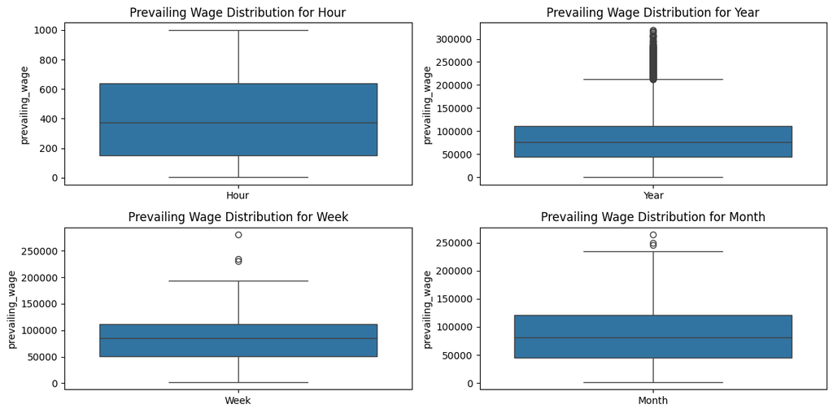

```python
# Create separate boxplots for each 'unit_of_wage' and 'prevailing_wage'
plt.figure(figsize=(12, 6))

for val in data['unit_of_wage'].unique():
    subset = data[data['unit_of_wage'] == val]
    plt.subplot(2, 2, list(data['unit_of_wage'].unique()).index(val) + 1)
    sns.boxplot(x='unit_of_wage', y='prevailing_wage', data=subset)
    plt.title(f'Prevailing Wage Distribution for {val}')
    plt.xlabel('')

plt.tight_layout()
plt.show()
```

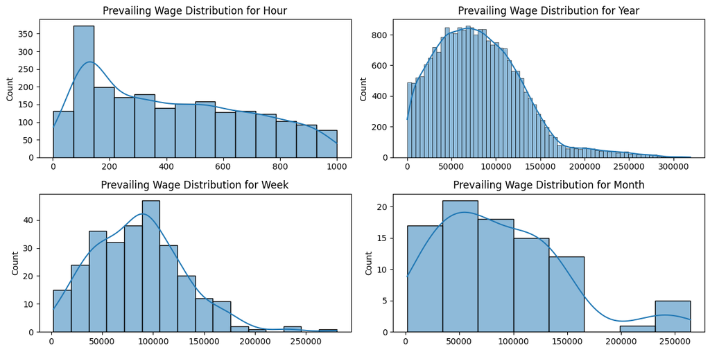

```python
# Create separate histograms for each 'unit_of_wage' and 'prevailing_wage'
plt.figure(figsize=(12, 6))

for val in data['unit_of_wage'].unique():
    subset = data[data['unit_of_wage'] == val]
    plt.subplot(2, 2, list(data['unit_of_wage'].unique()).index(val) + 1)
    sns.histplot(data=subset, x='prevailing_wage', kde=True)
    plt.title(f'Prevailing Wage Distribution for {val}')
    plt.xlabel('')


plt.tight_layout()
plt.show()
```

```python
data.info()
```

```
<class 'pandas.core.frame.DataFrame'>
RangeIndex: 25480 entries, 0 to 25479
Data columns (total 11 columns):
 #   Column                 Non-Null Count  Dtype
---  ------                 --------------  -----
 0   continent              25480 non-null  object
 1   education_of_employee  25480 non-null  object
 2   has_job_experience     25480 non-null  object
 3   requires_job_training  25480 non-null  object
 4   no_of_employees        25480 non-null  int64
 5   yr_of_estab            25480 non-null  int64
 6   region_of_employment   25480 non-null  object
 7   prevailing_wage        25480 non-null  float64
 8   unit_of_wage           25480 non-null  object
 9   full_time_position     25480 non-null  object
 10  case_status            25480 non-null  int64
dtypes: float64(1), int64(3), object(7)
memory usage: 2.1+ MB
```